# Combined analysis of miRNAseq and RUVs-corrected stranded library

```r
knitr::opts_chunk$set(echo = TRUE)
knitr::opts_chunk$set(include = TRUE)
knitr::opts_chunk$set(fig.width = 6)
knitr::opts_chunk$set(fig.height = 5)
library(greekLetters)
library(multiMiR)
library('org.Hs.eg.db')
library(biomaRt)
library(clusterProfiler)
library(enrichplot)
library(ggvenn)
library(eulerr)
library(tidyverse)
library(ggprism)
library(rcartocolor)
library(psych)
```

Define all helper functions and color choices

```r
theme_set(theme_prism(base_size = 14))
#Set color choices from CARTOcolors
discrete_pal_choice <- "Bold"
cont_pal_choice <- "BluYl"
diverg_pal_choice <- "Geyser"
#Helper functions
calc_relative <- function(x) x/sum(x) * 100
```

The next step is to perform multimir analysis on the mRNA and miRNA data - identify potential regulation of mRNA by miRNA. Read in tables of differential expression results and extract DE genes.

```r
mi_res <- read.csv(here::here("long_infection_human_reads/integrated analysis/data/mirna_normalized results.csv"), header = T)
#Select just the upregulated and downregulated miRNA
mi_filt_up <- mi_res %>%
  filter(padj.WTvsN < 0.1 & log2FoldChange.WTvsN > 0) %>%
  mutate(comb_name = str_c(Mature.miRNA,Precursor.miRNA, sep = "_"))
mi_filt_down <- mi_res %>%
  filter(padj.WTvsN < 0.1 & log2FoldChange.WTvsN < 0) %>%
  mutate(comb_name = str_c(Mature.miRNA,Precursor.miRNA, sep = "_"))
#identify miRNA that are not officially differentially expressed, but don't appear in both WTvsUI and NvsUI comparisons
wt_de_mirna <- mi_res %>%
  filter(padj.WTvsUI < 0.1) %>%
  mutate(comb_name = str_c(Mature.miRNA,Precursor.miRNA, sep = "_"))
n_de_mirna <- mi_res %>%
  filter(padj.NvsUI < 0.1) %>%
  mutate(comb_name = str_c(Mature.miRNA,Precursor.miRNA, sep = "_"))
```

Visualize DE miRNA across all comparisons

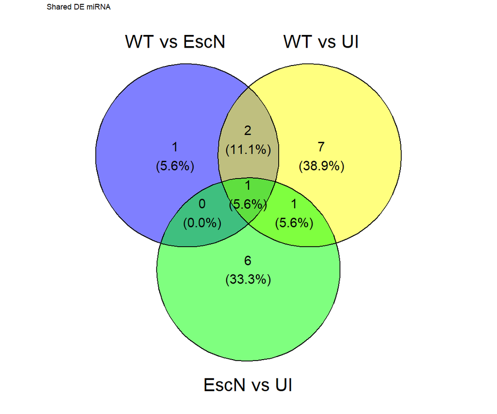

```r
de_mirna <- list(`WT vs EscN` = mi_filt_up$Mature.miRNA, `WT vs UI` = wt_de_mirna$Mature.miRNA, `EscN vs UI` = n_de_mirna$Mature.miRNA) %>%
  map(str_remove,"hsa-miR-")
#pdf(here::here("long_infection_human_reads/integrated analysis/results/Venn diagrams of shared differentially expressed miRNA.pdf"), width = 12, height = 10)
ggvenn(de_mirna, show_elements = F, text_size = 8, set_name_size = 11) + labs(title = "Shared DE miRNA")
```

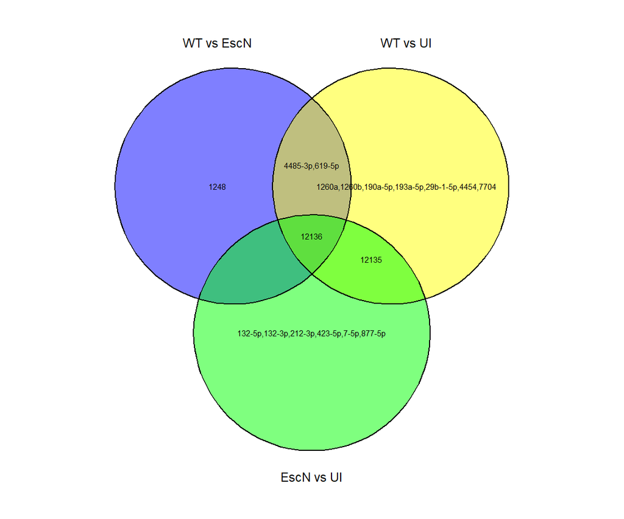

```r
ggvenn(de_mirna, show_elements = T)
```

```r
#dev.off()
```

From this it is evident, that DE miRNA are quite different across conditions WtvsUI and EscNvsUI, so let’s investigate why they don’t show up as WTvsEscN

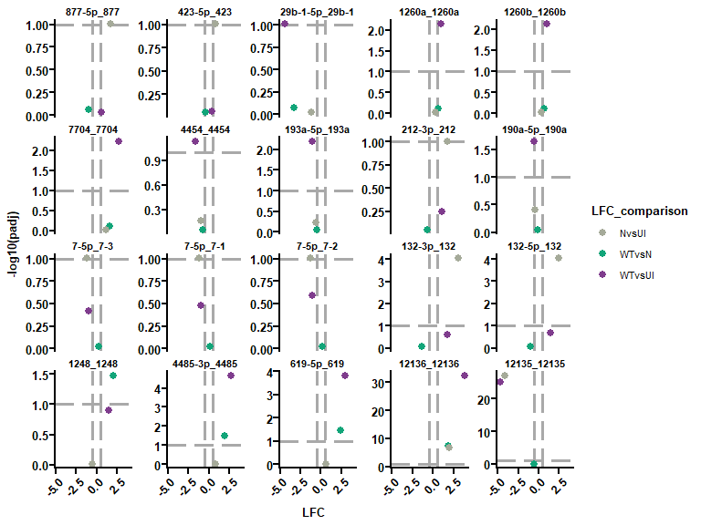

```r
de_mirna_lfc <- bind_rows(mi_filt_up,wt_de_mirna,n_de_mirna) %>%
  distinct() %>%
  dplyr::select(comb_name, matches("log")) %>%
  pivot_longer(-c(comb_name),names_to = "LFC_comparison", values_to = "LFC")
de_mirna_p <- bind_rows(mi_filt_up,wt_de_mirna,n_de_mirna) %>%
  distinct() %>%
  dplyr::select(comb_name, matches("padj")) %>%
  pivot_longer(-c(comb_name), names_to = "padj_comparison", values_to = "padj")
de_mirna <- bind_cols(de_mirna_lfc,dplyr::select(de_mirna_p,-comb_name)) %>%
  mutate(comb_name = str_remove_all(comb_name,"hsa-mi[rR]-"),
         LFC_comparison = str_remove(LFC_comparison, "log2FoldChange\\."))

ggplot(de_mirna) +
  geom_hline(aes(yintercept=1), linetype = "longdash", lwd = 1.2, color = "darkgrey") +
  geom_vline(aes(xintercept=0.5), linetype = "longdash", lwd = 1.2, color = "darkgrey")+
  geom_vline(aes(xintercept=-0.5), linetype = "longdash", lwd = 1.2, color = "darkgrey")+
  geom_point(aes(x=LFC,y=-log10(padj), color = LFC_comparison), size = 2.5) +
  scale_color_carto_d(palette = "Bold", direction = -1) +
  facet_wrap(~fct_reorder(comb_name,-log10(padj)), scales = "free_y") +
  theme_prism(base_size = 10, axis_text_angle = 45) +
  theme(legend.title = element_text())
```

```r
#ggsave(here::here("long_infection_human_reads/integrated analysis/results/Volcano plots of all DE miRNA.png"), width = 8, height = 6, dpi = 1080)
```

So I think, it is reasonable to select miRNA that are not shared between WTvsUI and EscNvsUI comparisons even though they don’t pass FDR to be officially. Only choose the miRNA that have a reasonable log2fold change between WT and EscN - lfc of 0.4 (change of 1.3)

```r
de_mirna_choice <- bind_rows(mi_filt_up,wt_de_mirna,n_de_mirna) %>%
  distinct(Mature.miRNA, .keep_all = T)
#Create a vector to contain all chosen miRNA
mirna_to_keep <- vector(mode ="character", length = nrow(de_mirna_choice))
j <- 1
#Populate the vector with chosen miRNA
for (i in 1:nrow(de_mirna_choice)) {
  if (de_mirna_choice$padj.WTvsN [i] < 0.1) {
   mirna_to_keep [j] <- de_mirna_choice$Mature.miRNA [i]
   j <- j+1
  } else if (abs(de_mirna_choice$log2FoldChange.WTvsN) [i] >= 0.4) {
    mirna_to_keep [j] <- de_mirna_choice$Mature.miRNA [i]
   j <- j+1
  }
}
#Get the top up and down regulated miRNA from the chosen vector
mi_filt_up <- de_mirna_choice %>%
  filter(Mature.miRNA %in% mirna_to_keep & log2FoldChange.WTvsN > 0)
top_miRNA_up <- mi_filt_up$Mature.miRNA
mi_filt_down <- de_mirna_choice %>%
  filter(Mature.miRNA %in% mirna_to_keep & log2FoldChange.WTvsN < 0)
top_miRNA_down <- mi_filt_down$Mature.miRNA
```

Next step is to prepare DE mRNA from WTvsN condition and perform multimiR analysis. Selecting DE with looser parameters to capture more potential relationships.

```r
#Select just the upregulated and downregulated mRNA
m_res <- read.csv(here::here("long_infection_human_reads/integrated analysis/data/RUVs normalized results.csv"), header = T)
m_filt_up <- m_res %>%
  filter(padj.WTvsN < 0.1 & log2FoldChange.WTvsN > 0)
top_mRNA_up <- str_remove(m_filt_up$Gene.ID,"\\.[1-9]([0-9])?")
m_filt_down <- m_res %>%
  filter(padj.WTvsN < 0.1 & log2FoldChange.WTvsN < 0)
top_mRNA_down <- m_filt_down$Gene.ID %>% str_remove("\\.[1-9]([0-9])?")
```

Query the top miRNA hits with the multiMIR databases

```r
#Try to profile interactions between miRNA and DE genes (first match upregulated miRNA and downregulated mRNA)
mlt_int_mi_up <- get_multimir(org     = "hsa",
                         mirna   = top_miRNA_up,
                         target  = top_mRNA_down,
                         table   = "validated",
                         summary = TRUE,
                         predicted.cutoff.type = "p",
                         predicted.cutoff      = 20,
                         use.tibble = TRUE)
```

```
Searching mirecords ...
```

```
Searching mirtarbase ...
Searching tarbase ...
```

```r
inter_tbl_mi_up <- mlt_int_mi_up@data  %>%
  group_by(mature_mirna_id, target_symbol) %>%
  distinct(mature_mirna_id, target_ensembl) %>%
  mutate(mirna_expression = "up", mRNA_expression = "down")

#Now match downregulated miRNA and upregulated mRNA
mlt_int_mi_down <- get_multimir(org     = "hsa",
                         mirna   = top_miRNA_down,
                         target  = top_mRNA_up,
                         table   = "validated",
                         summary = TRUE,
                         predicted.cutoff.type = "p",
                         predicted.cutoff      = 20,
                         use.tibble = TRUE)
```

```
Searching mirecords ...
Searching mirtarbase ...
Searching tarbase ...
```

```r
inter_tbl_mi_down <- mlt_int_mi_down@data %>%
  group_by(mature_mirna_id, target_symbol) %>%
  distinct(mature_mirna_id, target_ensembl) %>%
  mutate(mirna_expression = "down", mRNA_expression = "up")
final_int <- rbind(inter_tbl_mi_up, inter_tbl_mi_down) %>%
  mutate(symbol = case_when(
    nchar(target_symbol) == 0 ~ target_ensembl,
    TRUE ~ target_symbol))
#write.table(final_int, here::here("long_infection_human_reads/integrated analysis/results/network/multimir miRNA-RUVsmRNA WTvsN validated interactions.txt"), sep = "\t", row.names = F, quote = F)
#Now we can make a table with attributes (gene species, and expression up, or down)
top_mrna <-  final_int %>%
  ungroup() %>%
  dplyr::select(geneid = target_ensembl, expr = mRNA_expression, symbol) %>%
  mutate(species = "mrna") %>%
  filter(!duplicated(symbol))
top_genes <- final_int %>%
  ungroup() %>%
  dplyr::select(geneid = mature_mirna_id,expr = mirna_expression) %>%
  mutate(species = "mirna",
         symbol = geneid) %>%
  filter(!duplicated(symbol)) %>%
  bind_rows(top_mrna)
#Create a mapping for ID to genetype
geneids <- mapIds(org.Hs.eg.db, keys = top_genes$geneid,
                  keytype = "ENSEMBL", column = "GENETYPE", multiVals = "first") %>%
  as.data.frame() %>%
  rownames_to_column(var = "geneid") %>%
  dplyr::rename("biotype" = ".")
#Apply the symbol mapping
top_genes <- top_genes %>%
  left_join(geneids) %>%
  mutate(biotype = case_when(
    is.na(biotype) ~ species,
    TRUE ~ biotype
  ))
```

Apply functional profiling to the identified clusters. #008080,#70a494,#b4c8a8,#f6edbd,#edbb8a,#de8a5a,#ca562c

```r
#Get the stranded and miRNA genes
mrna_genes <- m_res %>%
  dplyr::select(geneid = Gene.ID,log2FoldChange.WTvsN) %>%
  mutate(geneid = str_remove(geneid, "\\.[1-9]([0-9])?")) %>%
  filter(geneid %in% top_genes$geneid) %>%
  left_join(dplyr::select(top_genes,geneid,symbol)) %>%
  dplyr::select(-geneid)
#Map miRNA genes to their symbols
#Create a mapping for miRNA ID to symbol
#Prepare a mart object for mapping miRNA names to
mart <- useEnsembl(dataset = "hsapiens_gene_ensembl", biomart='ensembl')
mirs <- top_genes [top_genes$species == "mirna",] $geneid %>% str_remove("-.p") %>% str_to_lower()
annot <- getBM(attributes=c('hgnc_symbol','mirbase_id'), filters='mirbase_id', values=mirs, mart=mart) %>%
  filter(nchar(hgnc_symbol) != 0)

mirna_genes <- mi_res %>%
  dplyr::select(geneid = Mature.miRNA,log2FoldChange.WTvsN) %>%
  filter(geneid %in% top_genes$geneid) %>%
  group_by(geneid) %>%
  slice_max(abs(log2FoldChange.WTvsN)) %>%
  mutate(precursor = str_to_lower(str_remove(geneid,"-.p"))) %>%
  left_join(annot, by = c("precursor" = "mirbase_id")) %>%
  filter(!is.na(hgnc_symbol), nchar(hgnc_symbol) != 0) %>%
  ungroup() %>%
  dplyr::select(log2FoldChange.WTvsN, symbol = hgnc_symbol)
#Join the gene list
gl_df <- bind_rows(mrna_genes,mirna_genes) %>%
  arrange(desc(log2FoldChange.WTvsN))
#Transform into the actual gene list object for clusterprofiler
gl <- set_names(gl_df$log2FoldChange.WTvsN, nm = gl_df$symbol)
```

Read in the pathway collection information

```r
#Read in set c5 from molecular signatures database - https://www.gsea-msigdb.org/gsea/msigdb/collections.jsp#H
#Biological pathway only
c5 <- read.gmt(here::here("long_infection_human_reads/integrated analysis/data/c5.go.bp.v7.5.1.symbols.gmt"))
h <- read.gmt(here::here("long_infection_human_reads/integrated analysis/data/h.all.v7.5.1.symbols.gmt"))
c2 <- read.gmt(here::here("long_infection_human_reads/integrated analysis/data/c2.cp.kegg.v7.5.1.symbols.gmt"))
```

Check which of the mRNA-miRNA association belong to apoptosis pathway

```r
#Identify genes with apoptotic annotation
top_genes_annot <- top_genes_symbol %>%
  left_join(c5, by = c("symbol" = "gene")) %>%
  left_join(h, by = c("symbol" = "gene"), suffix = c(".c5",".h")) %>%
  filter(str_detect(term.h, "APOP") | str_detect(term.c5, "APOP")) %>%
  distinct(symbol, .keep_all = T)
```

Perform functional profiling

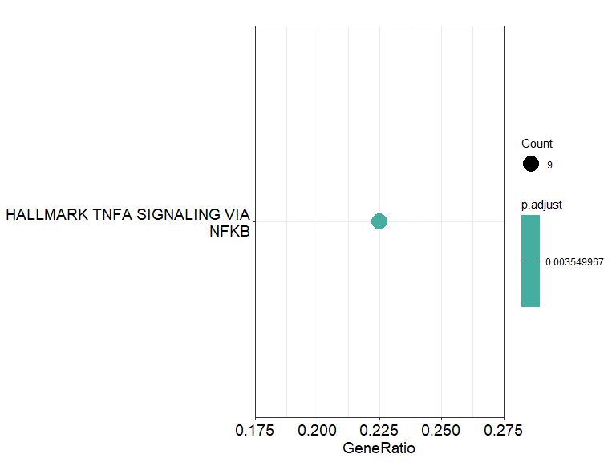

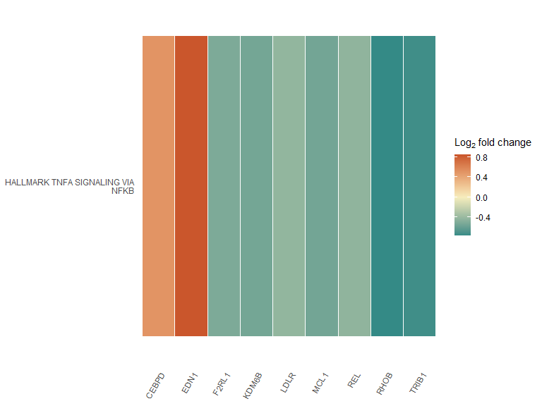

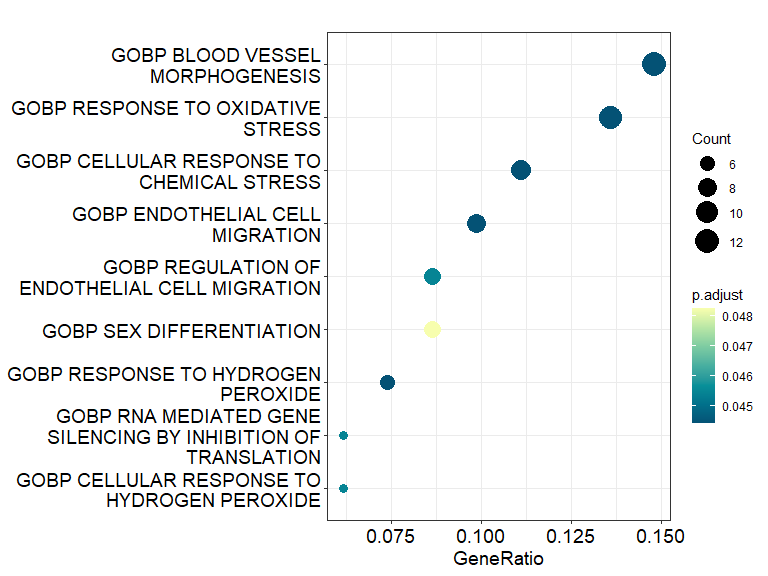

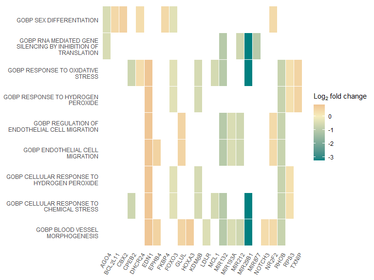

```r
#pdf(here::here("long_infection_human_reads/integrated analysis/results/clusterprofiler WTvsN results ora analysis with defined background list.pdf"), width = 8, height = 6)
for (i in c(1,3)) {
print(dotplot(ora [[i]], showCategory = 20, font.size = 14) +
        scale_color_carto_c(palette = cont_pal_choice, direction = -1))
print(heatplot(ora [[i]], foldChange=gl) +
        scale_fill_gradient2(high = carto_pal(7,diverg_pal_choice) [7],
                             low =  carto_pal(7,diverg_pal_choice) [1],
                             mid =  carto_pal(7,diverg_pal_choice) [4],
                             midpoint = 0,
                             name = bquote(Log[2] ~ "fold change")))
}
```

Repeat network analysis without separating up and down regulated genes

```r
top_genes <- top_genes %>%
  left_join(geneids) %>%
  mutate(biotype = case_when(
    is.na(biotype) ~ species,
    TRUE ~ biotype
  ),fdr = case_when(
    geneid %in% fdr_wtvsn_mirna ~
      'circoschart: arcwidth=0.25 firstarc=0 colorlist="coral" showlabels=false attributelist="circos"',
    symbol %in% h_tnf$gene ~ 'circoschart: arcwidth=0.25 firstarc=0 colorlist="purple" showlabels=false attributelist="circos1"',
    symbol %in% h_mtorc$gene ~ 'circoschart: arcwidth=0.25 firstarc=0 colorlist="brown" showlabels=false attributelist="circos1"'
  ))
```

```r
pdf(here::here("long_infection_human_reads/integrated analysis/results/clusterprofiler WTvsN combined search ora analysis with defined background list.pdf"), width = 8, height = 6)
for (i in 1) {
print(dotplot(ora [[i]], showCategory = 20, font.size = 17) +
        scale_color_gradient(high = chosen_cont_colors [1], low = chosen_cont_colors [4]) +
        scale_size(range = c(7,12)) +
        expand_limits(x = c(0.14, 0.21)) +
        theme(legend.text = element_text(size = 14),
              legend.title = element_text(size = 15)))
print(heatplot(ora [[i]], foldChange=gl) +
        scale_fill_gradient2(high = carto_pal(7,diverg_pal_choice) [7],
                             low =  carto_pal(7,diverg_pal_choice) [1],
                             mid =  carto_pal(7,diverg_pal_choice) [4],
                             midpoint = 0,
                             name = bquote(Log[2] ~ "fold change")))
}
dev.off()
```